# Correlations and Regression Models - Task Sheet

Series on Statistics - 2024

Philipp Mildenberger Institute of Medical Biostatistics, Epidemiology and Informatics (IMBEI) pmildenb@uni-mainz.de

2024-03-20

# 1 Correlation

## 1.1 Pearson’s Correlation

Welcome to the correlations tutorial. Your first task is to explore the bodyfat data from the R Package “TH.data”. The setup-script has created a smaller version of this dataset, now called `bodyfat.tutorial`. You should be able to find this data frame in your current global R environment. A description of the dataset can be found here: https://cran.r-project.org/web/packages/TH.data/TH.data.pdf or via `? bodyfat` in the console. The study it was taken from can be found here: https://onlinelibrary.wiley.com/doi/epdf/10.1038/oby.2005.67 .

Now check the type of all variables in the data and create pairwise scatterplots of all metric and ordinal variables. Please do not hesitate to ask the tutors if there are any questions!

```r
# check the name and class of all variables
kable(data.frame(lapply(bodyfat.tutorial, class)))
```

| age | DEXfat | waistcirc | hipcirc | elbowbreadth | kneebreadth |
| --- | --- | --- | --- | --- | --- |
| numeric | numeric | numeric | numeric | numeric | numeric |

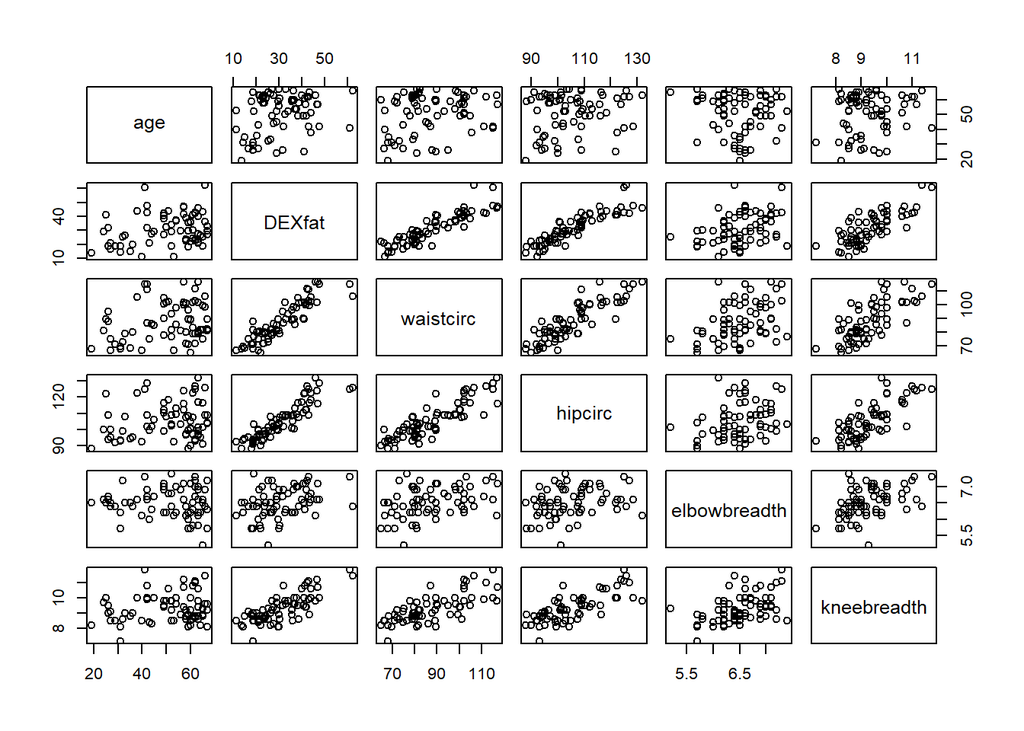

```r
# create a scatterplot matrix of all variable combinations
pairs(bodyfat.tutorial)
```

Now pick a pair of variables that appear to be highly correlated and create a single scatterplot of those two. Then calculate the Pearson’s and Spearman’s Correlation Coefficients and interpret the results. Which type of correlation would be more appropriate?

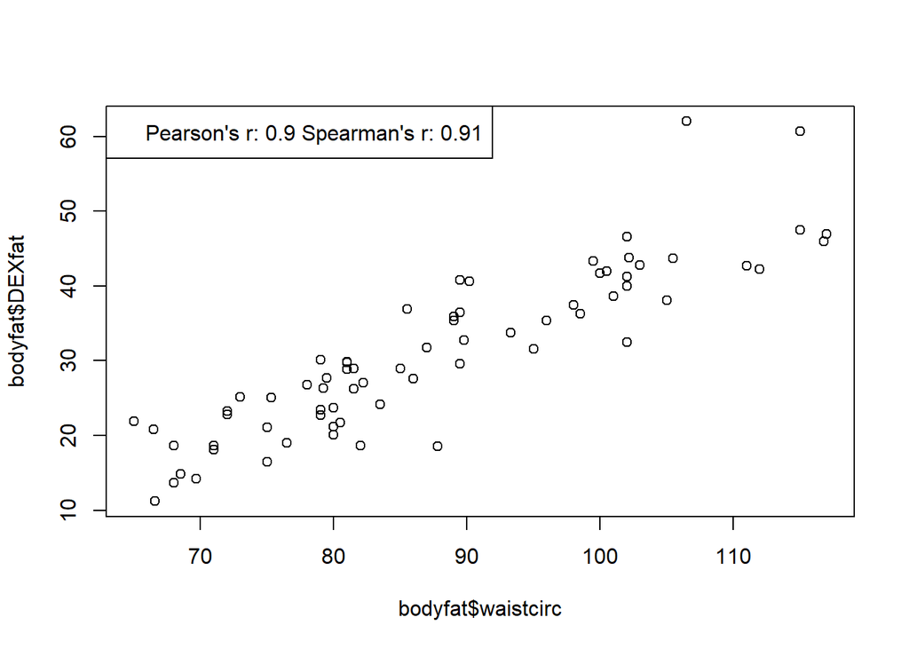

```r
# create a single scatterplot for close inspection and add the correlation coefficients
plot(bodyfat$waistcirc, bodyfat$DEXfat)
legend(x = "topleft",
       legend = paste("Pearson's r:",
                      round(cor(bodyfat$waistcirc,
                                bodyfat$DEXfat,
                                method = "pearson"),
                            2),
                      "Spearman's r:",
                      round(cor(bodyfat$waistcirc,
                                bodyfat$DEXfat,
                                method = "spearman"),
                            2)
                      )
       )
```

Now check the assumption for inferential statistics on Pearson’s correlation, i.e. that the distributions of values for each of the two variables follow a Normal Distribution. This can be done by plotting a QQ-Plot comparing each variable to a Normal Distribution.

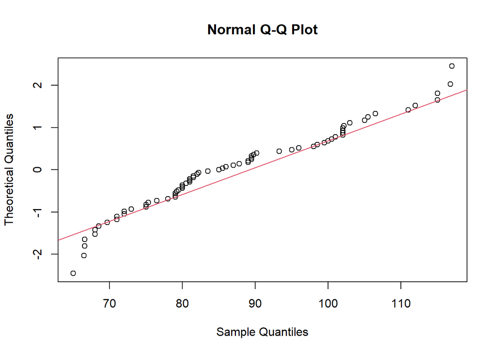

```r
# plot a qqplot of the first variable
qqnorm(bodyfat$waistcirc, datax = T)
qqline(bodyfat$waistcirc, datax = T, col = 2)
```

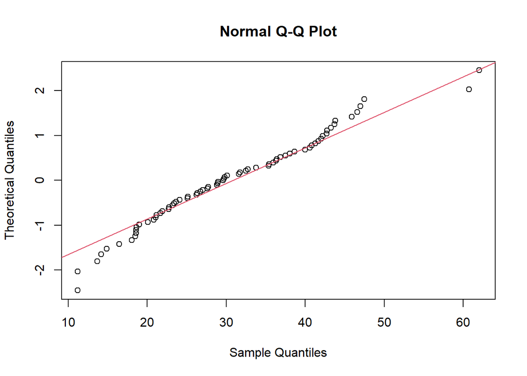

```r
# and of the second
qqnorm(bodyfat$DEXfat, datax = T)
qqline(bodyfat$DEXfat, datax = T, col = 2)
```

Now that you have checked if the distributional assumptions for inference on the correlation are met, you can go ahead and either use a more appropriate type of correlation or continue with Pearson’s correlation and calculate confidence intervals for the estimated correlation.

```r
# calculate confidence intervals for Pearson's correlation

# 90%
confidence_90 <- cor.test(bodyfat$waistcirc, bodyfat$DEXfat, method = "pearson", conf.level = 0.90)$conf.int

# 95%
confidence_95 <- cor.test(bodyfat$waistcirc, bodyfat$DEXfat, method = "pearson", conf.level = 0.95)$conf.int

# 99%
confidence_99 <- cor.test(bodyfat$waistcirc, bodyfat$DEXfat, method = "pearson", conf.level = 0.99)$conf.int

# display the three intervals in one table
kable(matrix(c(confidence_90, confidence_95, confidence_99),
       byrow = T,
       nrow = 3,
       ncol = 2,
       dimnames = list(Confidence = c("90%", "95%", "99%"), Bounds = c("Lower", "Upper"))
       ))
```

|  | Lower | Upper |
| --- | --- | --- |
| 90% | 0.8526306 | 0.9308402 |
| 95% | 0.8418517 | 0.9357654 |
| 99% | 0.8186836 | 0.9444302 |

## 1.2 Spearman’s Rank Correlation

The next tasks focus on another pair of variables from the artificial dataset “data.nl”: var1 and var2. You should find this data frame in your global R environment. Create a scatterplot of these two variables and calculate Pearson’s and Spearman’s correlation. What do you notice?

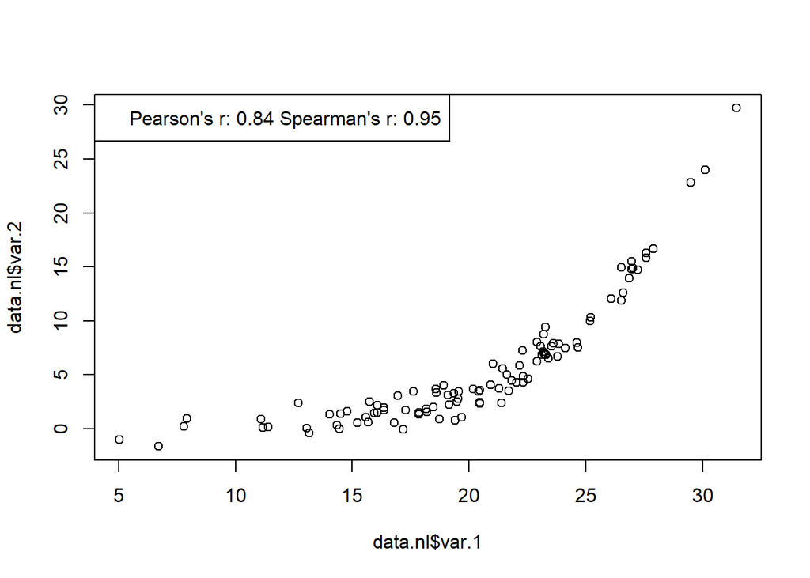

```r
# create the single scatterplot for close inspection
plot(data.nl$var.1, data.nl$var.2)
legend(x = "topleft",
       legend = paste("Pearson's r:",
                      round(cor(data.nl$var.1,
                                data.nl$var.2,
                                method = "pearson"),
                            2),
                      "Spearman's r:",
                      round(cor(data.nl$var.1,
                                data.nl$var.2,
                                method = "spearman"),
                            2)
                      )
       )
```

To better understand how Spearman’s Rank Correlation works, now transform var.1 and var.2 from “data.nl” by creating two columns (i.e. new variables), each containing the rank of an observation based on var.1 / var.2 . Hint: An R function you could use sounds a lot like what you want it to do…

After creating these two new variables, plot them in a scatterplot and calculate Pearson’s correlation coefficient. Then compare the result to you previously obtained two correlations. What do you notice?

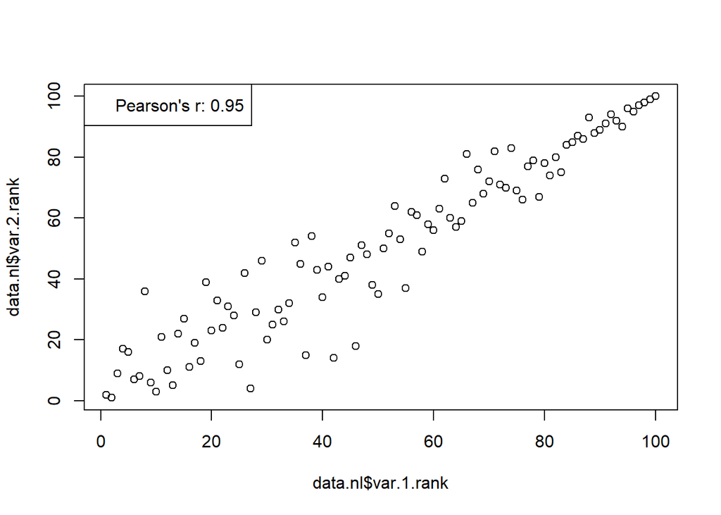

```r
# create a new column of ranks based on var.2
data.nl$var.1.rank <- rank(data.nl$var.1, ties.method = "average")
data.nl$var.2.rank <- rank(data.nl$var.2, ties.method = "average")


# create the  scatterplot and calculate the correlation
plot(data.nl$var.1.rank, data.nl$var.2.rank)
legend(x = "topleft",
       legend = paste("Pearson's r:",
                      round(cor(data.nl$var.1.rank,
                                data.nl$var.2.rank,
                                method = "pearson"),
                            2)
                      )
       )
```

# 2 Regression

## 2.1 Exercise 1 - `bodyfat` data

We want to take a look at the `bodyfat` data set in package `TH.data` again. The setup-script has already loaded the dataset. A description of the dataset can be found by typing `?bodyfat` in the console.

### 2.1.1 Model selection

The author’s stated objective was *“to develop improved predictive regression equations for body fat content derived from common anthropometric measurements.”* We now want to reproduce their results. The **response variable** will therefore be `DEXfat`. All the variables in the dataset have potential explanatory power and are thus potential **explanatory variables**.

First take a look at the scatterplot of `DEXfat` and `waistcirc` again:

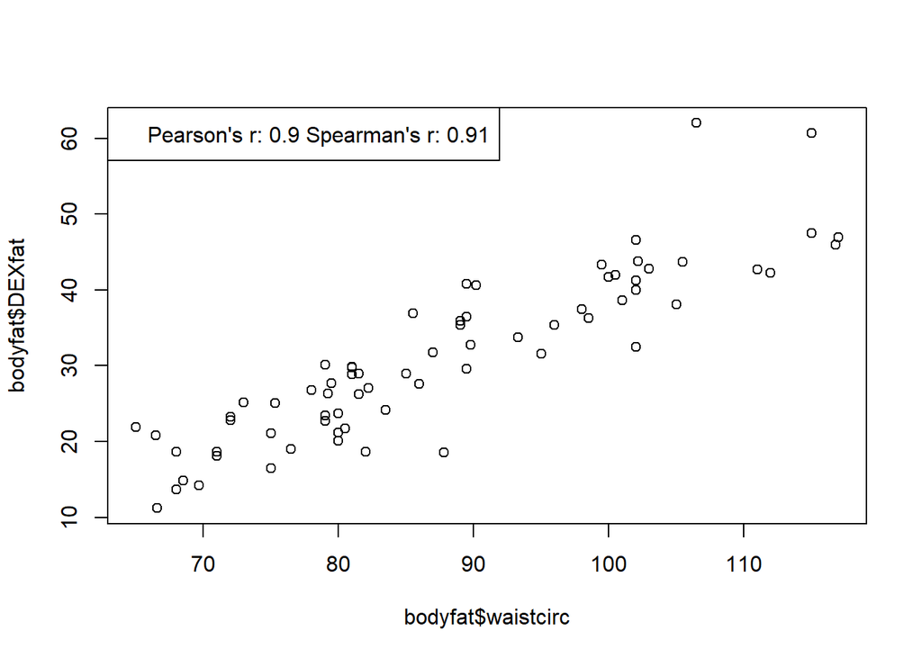

```r
plot(bodyfat$waistcirc,bodyfat$DEXfat)
legend(x = "topleft",
       legend = paste("Pearson's r:",
                      round(cor(bodyfat$waistcirc,
                                bodyfat$DEXfat,
                                method = "pearson"),
                            2),
                      "Spearman's r:",
                      round(cor(bodyfat$waistcirc,
                                bodyfat$DEXfat,
                                method = "spearman"),
                            2)
                      )
       )
```

Now create a simple linear model with `DEXfat` as response and `waistcirc` as explanatory variable, take a look at the coefficients and draw the regression line into the scatterplot.

```r
## create the model
body.lm1 <- lm(DEXfat ~ waistcirc, data=bodyfat)

## print the model
body.lm1
```

```
##
## Call:
## lm(formula = DEXfat ~ waistcirc, data = bodyfat)
##
## Coefficients:
## (Intercept)    waistcirc
##    -31.0316       0.7074
```

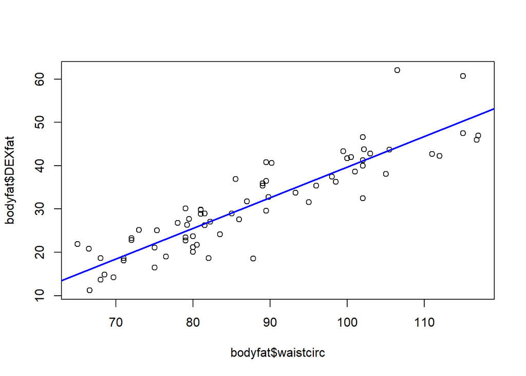

```r
## plot the scatter plot and add a line
plot(bodyfat$waistcirc,bodyfat$DEXfat)
abline(body.lm1$coefficients,col="blue",lwd=2)
```

What is the explained variance $R^2$ by `waistcirc`?

```r
## print the summary of the model
summary(body.lm1)
```

```
##
## Call:
## lm(formula = DEXfat ~ waistcirc, data = bodyfat)
##
## Residuals:
##      Min       1Q   Median       3Q      Max
## -12.5677  -3.6386  -0.3711   2.8719  17.7140
##
## Coefficients:
##              Estimate Std. Error t value Pr(>|t|)
## (Intercept) -31.03158    3.67831  -8.436 3.18e-12 ***
## waistcirc     0.70740    0.04157  17.017  < 2e-16 ***
## ---
## Signif. codes:  0 '***' 0.001 '**' 0.01 '*' 0.05 '.' 0.1 ' ' 1
##
## Residual standard error: 4.879 on 69 degrees of freedom
## Multiple R-squared:  0.8076, Adjusted R-squared:  0.8048
## F-statistic: 289.6 on 1 and 69 DF,  p-value: < 2.2e-16
```

```r
## .. or print only the R^2
summary(body.lm1)$r.squared
```

```
## [1] 0.8075781
```

We have seen the relation between $R^2$ and Pearson’s correlation $\rho$ in simple linear regression. Now verify this in R.  
Bonus: Verify the relation $\widehat\beta_1\frac{\text{sd}(x)}{\text{sd}(y)}=\rho$ between Pearson’s correlation and regression coefficient.

```r
## R^2 of the simple linear regression model
summary(body.lm1)$r.squared
```

```
## [1] 0.8075781
```

```r
## Pearson's correlation
cor.waist.fat <- cor(bodyfat$waistcirc,bodyfat$DEXfat, method="pearson")
## Pearson's correlation squared
cor.waist.fat^2
```

```
## [1] 0.8075781
```

```r
## regression coefficient beta_1
beta1 <- body.lm1$coefficients['waistcirc']

## beta_1 scaled with the sample deviations equals Pearson's correlation
rho <- beta1*sd(bodyfat$waistcirc)/sd(bodyfat$DEXfat)
names(rho) <- "Pearson's r"
rho
```

```
## Pearson's r
##   0.8986535
```

Now we want to select a second variable to improve the predictive power. Exemplary, construct two candidate models, the first by adding `hipcirc`as explanatory variable, the second by adding `elbowbreadth`.

```r
## fit the model with hipcirc added
body.lm2a <- lm(DEXfat ~ waistcirc + hipcirc, data=bodyfat)
## print a summary of the model
summary(body.lm2a)
```

```
##
## Call:
## lm(formula = DEXfat ~ waistcirc + hipcirc, data = bodyfat)
##
## Residuals:
##     Min      1Q  Median      3Q     Max
## -8.9135 -2.5354  0.3551  2.2543 13.9465
##
## Coefficients:
##              Estimate Std. Error t value Pr(>|t|)
## (Intercept) -53.48508    5.12745 -10.431 9.46e-16 ***
## waistcirc     0.36796    0.07105   5.179 2.16e-06 ***
## hipcirc       0.49501    0.09028   5.483 6.64e-07 ***
## ---
## Signif. codes:  0 '***' 0.001 '**' 0.01 '*' 0.05 '.' 0.1 ' ' 1
##
## Residual standard error: 4.093 on 68 degrees of freedom
## Multiple R-squared:  0.8666, Adjusted R-squared:  0.8626
## F-statistic: 220.8 on 2 and 68 DF,  p-value: < 2.2e-16
```

```r
## fit the model with elbowbreadth added
body.lm2b <- lm(DEXfat ~ waistcirc + elbowbreadth, data=bodyfat)
## print the model
summary(body.lm2b)
```

```
##
## Call:
## lm(formula = DEXfat ~ waistcirc + elbowbreadth, data = bodyfat)
##
## Residuals:
##      Min       1Q   Median       3Q      Max
## -12.5510  -3.6039  -0.4161   2.7402  17.6446
##
## Coefficients:
##              Estimate Std. Error t value Pr(>|t|)
## (Intercept)  -29.9907     8.4041  -3.569 0.000664 ***
## waistcirc      0.7099     0.0457  15.534  < 2e-16 ***
## elbowbreadth  -0.1939     1.4050  -0.138 0.890666
## ---
## Signif. codes:  0 '***' 0.001 '**' 0.01 '*' 0.05 '.' 0.1 ' ' 1
##
## Residual standard error: 4.914 on 68 degrees of freedom
## Multiple R-squared:  0.8076, Adjusted R-squared:  0.802
## F-statistic: 142.7 on 2 and 68 DF,  p-value: < 2.2e-16
```

Now use the **AIC**-criterion to compare the two candidate models to the model with only `waistcirc`.

```r
## calculate the AIC manually
aic.lm1  <- extractAIC(body.lm1)
aic.lm2a <- extractAIC(body.lm2a)
aic.lm2b <- extractAIC(body.lm2b)


## or by using the function stats::add1()
add1(body.lm1,c("hipcirc","elbowbreadth"),test = "Chisq")
```

```
## Single term additions
##
## Model:
## DEXfat ~ waistcirc
##              Df Sum of Sq    RSS    AIC  Pr(>Chi)
## <none>                    1642.5 227.03
## hipcirc       1    503.53 1139.0 203.04 3.427e-07 ***
## elbowbreadth  1      0.46 1642.0 229.01    0.8879
## ---
## Signif. codes:  0 '***' 0.001 '**' 0.01 '*' 0.05 '.' 0.1 ' ' 1
```

```r
## -> adding hipcirc is an improvement, adding elbowbreadth is not
```

Split the `bodyfat` data in two data sets. The first 26 observations shall become the test set `bodyfat.test`, observations 27 to 71 form the training set `bodyfat.training`.

```r
bodyfat.test     <- bodyfat[1:26,]   ## test set
bodyfat.training <- bodyfat[27:71,]  ## training set
```

Establish the full model (i.e. the model that contains all possible explanatory variables) on the training data

```r
## fit the full model to bodyfat.training
fullmodel <- lm(DEXfat ~ age + waistcirc + hipcirc + elbowbreadth +
                kneebreadth + anthro3a + anthro3b + anthro3c + anthro4,
                data = bodyfat.training)

## The same in short notation:
fullmodel <- lm(DEXfat ~ . ,data=bodyfat.training)
```

Now use **backward selection** with the **AIC**-criterion.

```r
step(fullmodel,direction="backward")
```

```
## Start:  AIC=121.59
## DEXfat ~ age + waistcirc + hipcirc + elbowbreadth + kneebreadth +
##     anthro3a + anthro3b + anthro3c + anthro4
##
##                Df Sum of Sq    RSS    AIC
## - anthro3c      1     0.257 430.44 119.62
## - age           1     0.655 430.84 119.66
## - anthro3b      1     4.078 434.26 120.01
## - anthro4       1     9.256 439.44 120.55
## - elbowbreadth  1    10.422 440.61 120.67
## - waistcirc     1    19.530 449.71 121.59
## <none>                      430.18 121.59
## - anthro3a      1    41.488 471.67 123.73
## - kneebreadth   1    97.006 527.19 128.74
## - hipcirc       1   111.132 541.32 129.93
##
## Step:  AIC=119.62
## DEXfat ~ age + waistcirc + hipcirc + elbowbreadth + kneebreadth +
##     anthro3a + anthro3b + anthro4
##
##                Df Sum of Sq    RSS    AIC
## - age           1     0.752 431.19 117.69
## - anthro3b      1     6.346 436.79 118.28
## - anthro4       1     9.241 439.68 118.57
## - elbowbreadth  1    10.226 440.67 118.67
## <none>                      430.44 119.62
## - waistcirc     1    24.687 455.13 120.13
## - anthro3a      1    41.281 471.72 121.74
## - kneebreadth   1    96.947 527.39 126.76
## - hipcirc       1   113.906 544.35 128.18
##
## Step:  AIC=117.7
## DEXfat ~ waistcirc + hipcirc + elbowbreadth + kneebreadth + anthro3a +
##     anthro3b + anthro4
##
##                Df Sum of Sq    RSS    AIC
## - anthro3b      1     5.978 437.17 116.31
## - anthro4       1     8.713 439.91 116.59
## - elbowbreadth  1    13.291 444.48 117.06
## <none>                      431.19 117.69
```

[output cut: 32 more lines]

```
##               Df Sum of Sq    RSS    AIC
## - waistcirc    1    15.187 472.72 113.83
## <none>                     457.54 114.36
## - kneebreadth  1   107.306 564.84 121.84
## - hipcirc      1   136.064 593.60 124.08
## - anthro3a     1   229.643 687.18 130.67
##
## Step:  AIC=113.83
## DEXfat ~ hipcirc + kneebreadth + anthro3a
##
##               Df Sum of Sq    RSS    AIC
## <none>                     472.72 113.83
## - kneebreadth  1    138.47 611.19 123.39
## - hipcirc      1    269.56 742.29 132.14
## - anthro3a     1    313.52 786.24 134.73
```

```
##
## Call:
## lm(formula = DEXfat ~ hipcirc + kneebreadth + anthro3a, data = bodyfat.training)
##
## Coefficients:
## (Intercept)      hipcirc  kneebreadth     anthro3a
##    -77.5626       0.4242       3.1222       8.7883
```

… and inspect the selected model with summary()

```r
##
body.lm.training <- lm(DEXfat ~ hipcirc + kneebreadth + anthro3a,
                       data=bodyfat.training)
summary(body.lm.training)
```

```
##
## Call:
## lm(formula = DEXfat ~ hipcirc + kneebreadth + anthro3a, data = bodyfat.training)
##
## Residuals:
##     Min      1Q  Median      3Q     Max
## -6.5712 -1.7688 -0.7065  1.8974  9.7577
##
## Coefficients:
##              Estimate Std. Error t value Pr(>|t|)
## (Intercept) -77.56262    4.98550 -15.558  < 2e-16 ***
## hipcirc       0.42424    0.08774   4.835 1.90e-05 ***
## kneebreadth   3.12217    0.90094   3.465  0.00125 **
## anthro3a      8.78825    1.68532   5.215 5.61e-06 ***
## ---
## Signif. codes:  0 '***' 0.001 '**' 0.01 '*' 0.05 '.' 0.1 ' ' 1
##
## Residual standard error: 3.396 on 41 degrees of freedom
## Multiple R-squared:  0.9321, Adjusted R-squared:  0.9271
## F-statistic: 187.5 on 3 and 41 DF,  p-value: < 2.2e-16
```

### 2.1.2 Model assessment

Evaluate the test error, i.e. the prediction error of the model applied to the test data.

```r
## make predictions
prediction <- predict.lm(body.lm.training,bodyfat.test)

## calculate the prediction error
pred.error <- bodyfat.test$DEXfat - prediction

## and it's standard deviation
sd(pred.error)
```

```
## [1] 3.765598
```

```r
## Residual/Total sum of squares
RSS <- sum(pred.error^2)
TSS <- sum((bodyfat.test$DEXfat - mean(bodyfat.test$DEXfat))^2)


Rsquared <- 1-RSS/TSS
Rsquared
```

```
## [1] 0.7247262
```

Now fit the model to the complete data set and compare your result to the one given in the example of `?bodyfat`

```r
body.lm.final <- lm(DEXfat ~ hipcirc + kneebreadth + anthro3a, data=bodyfat)
```

Use the `stats::plot.lm()`-function (same as the `plot`-method on `lm`-objects) to assess the fit of the model. Check `?plot.lm` for more detail on the function.

1. Is there structure in the residuals left?
2. Are the residuals approximately normally distributed?
3. Is the assumption of constant variance satisfied?
4. Are there individual data points with high leverage?

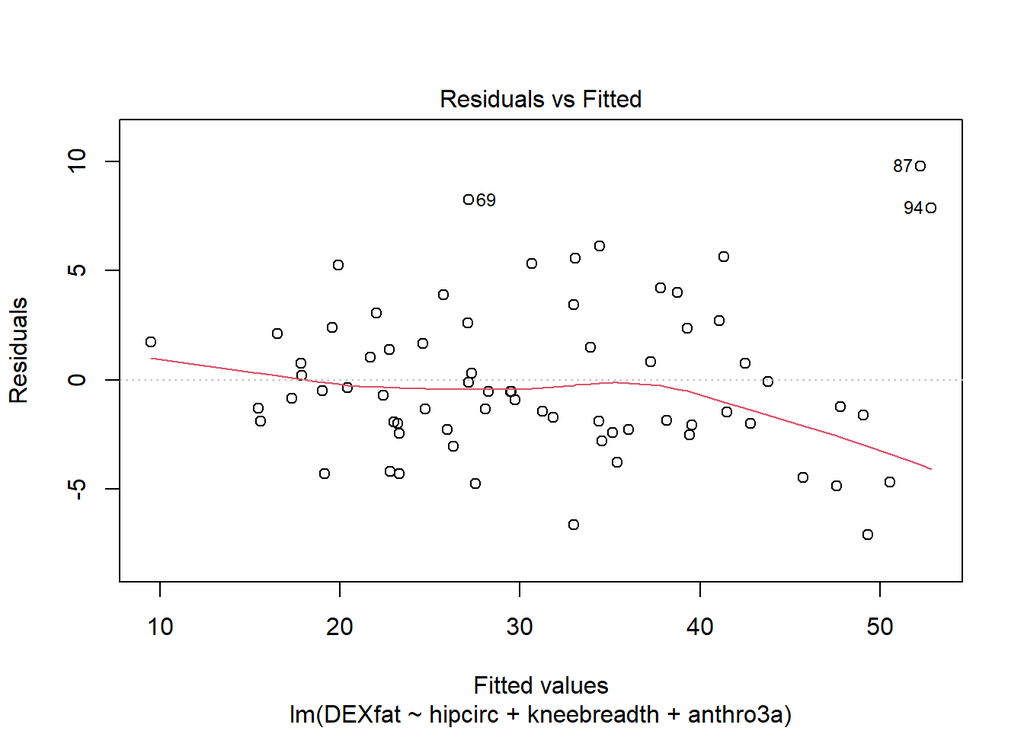

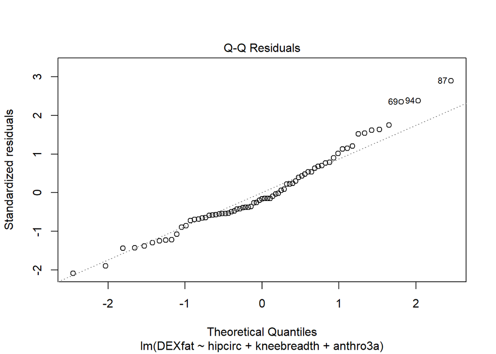

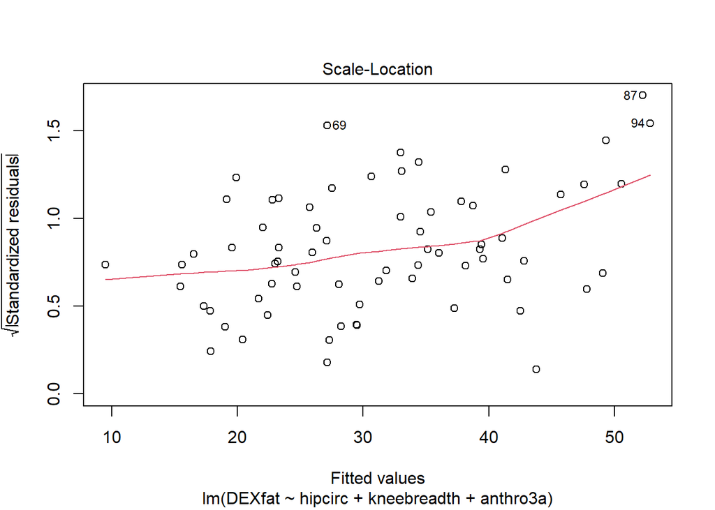

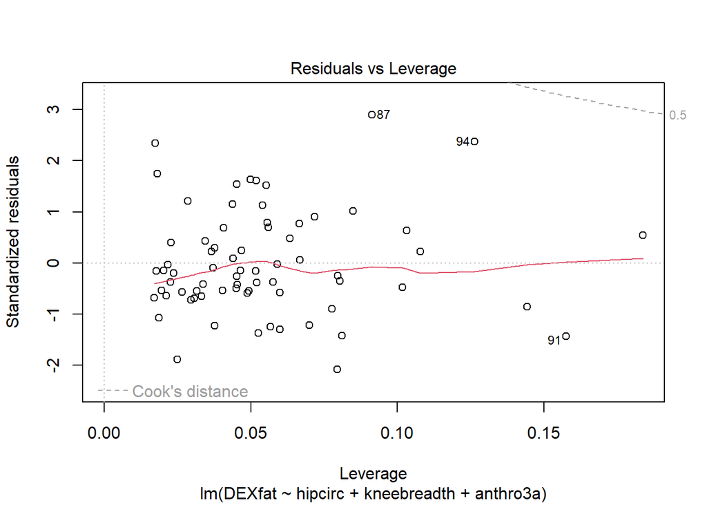

```r
plot(body.lm.final)
```

```r
## 1. Larger fitted values tend to have smaller residuals, hints at non-constant variance.
## 2. The QQ-plot looks fine.
## 3. In the third plot (sqrt(standardized residuals) vs Fitted values), a weak
##    trend in the form of "higher fitted values -> higher variance" is vaguely visible.
##    One could try if transformations of the explanatory variables
##    like sqrt() or log() are an improvement. In this specific case, it might
##    justified to assume that the volume of bodyfat is not proportional to the
##    circumference, but rather the cubic root of the circumference.
## 4. The fourth plot (Residuals vs Leverage) shows no critical individual
##    observations
```

## 2.2 Exercise 2 - `Dosis` data

### 2.2.1 Sample size: Case 1 - unadjusted

In some routinely collected data, you found a correlation between the dosis of a fequently given drug $D$ and a biomarker $B$, which is not known in the literature. Your aim is now to conduct a prospective study to examine whether this appeared merely at random in your `Dosis` data, or if there is indeed a relationship. How many subjects do you need to test this with a power of 90% to a significance level of 5% ?

```r
## simulate the data set
set.seed(21)
N   <- 200
age <- runif (N,25,70)
sex <- rbinom(N,1,0.5)
Dos <- 1+ rbeta(N,3,3) + 0.2*sex - 0.001 * age
Bio <- 50 + 25*Dos + age + 20*sex +  rnorm(N,0,25)

Dosis <- data.frame(Dos,age,sex,Bio)


## calculate R^2
R2_Dos     <-  summary(lm(Bio~Dos,data=Dosis))$r.squared

## calculate f^2
f2_Dos     <- R2_Dos/(1-R2_Dos)



## calculate sample size of F-test for Dosis only
## the argument that is not given to the function pwr.f2.test() is calculated.
## (Check also ?pwr.f2.test()). So in this case, the denominator degrees of
## freedom v are calculated.
pwr.f2.test(1,f2=f2_Dos,power = 0.9)
```

```
##
##      Multiple regression power calculation
##
##               u = 1
##               v = 118.6211
##              f2 = 0.08854495
##       sig.level = 0.05
##           power = 0.9
```

```r
## -> ceiling(v) + 2 = 121 subjects are needed
```

### 2.2.2 Statistical Inference: Case 1 - unadjusted

You now conducted your study and managed to include 150 subjects.

Now take a look at the `Dosis.prospective150` data set. Can you reject your null hypothesis, that Dosis and Biomarker are independent?

```r
## some artificial data
set.seed(8)
N   <- 270
age <- runif (N,25,70)
sex <- rbinom(N,1,0.5)
Dos <- 1+ rbeta(N,3,3) + 0.2*sex - 0.001 * age
Bio <- 50 + 25*Dos + age + 20*sex +  rnorm(N,0,25)

Dosis.prospective270 <- data.frame(Dos,age,sex,Bio)
Dosis.prospective150 <- Dosis.prospective270[1:150,]
```

```r
## linear model with response Biomarker and single predictive variable Dosis
summary(lm(Bio ~ Dos, data = Dosis.prospective150))
```

```
##
## Call:
## lm(formula = Bio ~ Dos, data = Dosis.prospective150)
##
## Residuals:
##     Min      1Q  Median      3Q     Max
## -60.870 -20.987  -2.368  20.883  81.660
##
## Coefficients:
##             Estimate Std. Error t value Pr(>|t|)
## (Intercept)    88.21      17.31   5.097 1.04e-06 ***
## Dos            37.55      11.16   3.365 0.000977 ***
## ---
## Signif. codes:  0 '***' 0.001 '**' 0.01 '*' 0.05 '.' 0.1 ' ' 1
##
## Residual standard error: 29.06 on 148 degrees of freedom
## Multiple R-squared:  0.07105,    Adjusted R-squared:  0.06478
## F-statistic: 11.32 on 1 and 148 DF,  p-value: 0.0009765
```

```r
## The last line of the summary lets you reject the null hypothesis.
## The F-test on a simple linear model returns the same p-value as the t-test
## on the coefficient.
```

### 2.2.3 Sample Size: Case 2 - adjusted for age and sex

$age$ and $sex$ are known to influence the Biomarker (and have also an influence on the Dosis given), so the test should be adjusted for those two variables. How many subjects do you need in this case?

```r
## calculate R^2
R2_age.sex <-  summary(lm(Bio~age+sex,data=Dosis))$r.squared
R2_all     <-  summary(lm(Bio~.,data=Dosis))$r.squared

## calculate f^2
f2_adj     <- (R2_all - R2_age.sex)/(1 - R2_all)

## calculate sample size of F-test for Dosis, adjusted for age and sex
pwr.f2.test(u=1,f2=f2_adj,power = 0.9)
```

```
##
##      Multiple regression power calculation
##
##               u = 1
##               v = 257.5637
##              f2 = 0.04078526
##       sig.level = 0.05
##           power = 0.9
```

```r
## -> ceiling(v) + 4 = 262 subjects are needed
```

Suppose the possible number of subjects is limited to 200 for logistical reasons. You now want to assess whether it is still worth conducting your study, i.e. you want to know the power for 200 subjects.

```r
## First calculate the degrees of freedom v: subjects - degrees of the model
v = 200 - 4

## calculate power of F-test for 250 subjects
pwr.f2.test(u=1,v=v,f2_adj,sig.level = 0.05)
```

```
##
##      Multiple regression power calculation
##
##               u = 1
##               v = 196
##              f2 = 0.04078526
##       sig.level = 0.05
##           power = 0.8072557
```

```r
## -> the power of the test would be 80.7%. In most contexts, this is still
##  considered acceptable high. You might want to run your study even if you
## could only include 200.
```

### 2.2.4 Statistical Inference: Case 2 - adjusted for age and sex

You managed to include 270 subjects into your prospective study.

Now take a look at the `Dosis.prospective270` data set. Can you reject your null hypothesis, that Dosis and Biomarker are independent, adjusted for $age$ and $sex$?

```r
dosis.fullmodel <- lm(Bio ~ .        , data = Dosis.prospective270)
dosis.agesex    <- lm(Bio ~ age + sex, data = Dosis.prospective270)

## compare the variances with an F-test.
## The easiest way to do that in R is the anova()-function on the two lm-objects:
anova(dosis.agesex,dosis.fullmodel)
```

```
## Analysis of Variance Table
##
## Model 1: Bio ~ age + sex
## Model 2: Bio ~ Dos + age + sex
##   Res.Df    RSS Df Sum of Sq     F  Pr(>F)
## 1    267 176964
## 2    266 173932  1    3032.7 4.638 0.03217 *
## ---
## Signif. codes:  0 '***' 0.001 '**' 0.01 '*' 0.05 '.' 0.1 ' ' 1
```

```r
## -> which return a p-value of around 3% and lets you reject the null hypothesis.
```

# 3 A short step-by-step guide

## 3.1 First things first

Before any data analysis you will be about to conduct, one big question has to be clarified:  
*Will you perform confirmatory or exploratory analysis?*

- **exploratory:** your aim usually is to discover the variables that best explain the response
- **confirmatory:** you have a specified hypothesis that seeks confirmation

In exploratory analysis, usually several regression models are **specified** and **compared** to **select** a winner of these candidate models.

For rigorous confirmatory analyses however, the analysis model needs to be specified before touching the data. The steps are

1. model / hypothesis specification
2. sample size calculation
3. unbreak the blinding of the investigator
4. model assessment
5. statistical inference

## 3.2 Model selection

### 3.2.1 Model specification

- Formulate what you want to investigate
  - What is the response variable?
  - Which potential explanatory variables should be considered?
- Choose an adequate regression model, depending on the
  - response variable:
    - continuous $\Rightarrow$ linear
    - binary $\Rightarrow$ logistic (or probit)
    - categorical $\Rightarrow$ ordinal
    - count $\Rightarrow$ poisson
    - survival $\Rightarrow$ coxPH,…
    - …
  - structure of the data:
    - if the data are clustered (e.g. repeated measures) $\Rightarrow$ mixed models, which include random effect terms, can be applied
    - other fitting approaches than minimizing the RSS can be useful (i.e. Lasso in high-dimensional data)
    - …

### 3.2.2 Model comparison

Model comparison is mainly relevant in exploratory settings. Popular methods are

- ANOVA *(for nested models only)*
- Comparisons of information criteria, e.g. **AIC**
- Comparisons of likelihoods
- (Test error comparisons via **cross-validation**)

These methods (especially ANOVA and AIC) are often used iteratively to select a favoured set of variables.

- **Forward selection:** start with a minimal model and add the “best” variable in each step. Stop if the method finds no further improvement.
- **Backward selection:** start with the maximal model and then drop the least informative variable in each step. Stop if the method finds no further improvement.

## 3.3 Sample size calculation

In exploratory analysis, sample size calculation is usually not feasible - in a confirmatory (prospective) setting,  
the needed sample size can (and should) be calculated. But in order to do this, a few things need to be specified:

- fully specified hypothesis, that means
  - a specified model, and
  - a statistical test
  - a **significance level** $\alpha$
- the **power** one aspires to achieve *(often set to 80% or 90%)*
- an assumed **effect size**

## 3.4 Model Assessment

After conducting any regression analysis, one should check the appropriateness of the model. There is no recommendend straightforward way to test for violations of the assumptions, but the important assumptions can be checked visually:

1. that no structure in the residuals is apparent
2. that the residuals are approximately normally distributed
3. that the variance of the residuals is constant (homoscedastic)
4. that there are no highly influential individuals (outliers)

In exploratory analysis, if any of the above seems violated, restart at model selection. In confirmative analysis, all one can still do is discussing the effect of these violations.

Another important method is assessing the prediction error (**test error**) for data not used to fit the model. Therefore, one splits the in two subsets, one set to fit (in this setting often called **train**) the model, the other to validate (**test**) it. An even more sophisticated way to do this is **cross-validation**.

## 3.5 Statistical Inference

In a confirmatory setting, one now can finally evaluate the initial hyphothesis.

# 4 Further reading

## 4.1 on Power Analysis

- A useful tool for power calculations for almost all kinds of tests is G*Power: http://gpower.hhu.de/. It tends to be technical, but has a good manual.
- Cohen J.(1977), *Statistical Power Analysis for the Behavioral Sciences* - still one of the best works to understand effect sizes

## 4.2 on Regression

- Fox (2016), *Applied Regression Analysis and Generalized Linear Models, Third Edition*
- Fox and Weisberg (2011), *An R Companion to Applied Regression, Second Edition*
- Fahrmeir, Kneip and Lang (2009), *Regression* (german)
- James, Witten, Hastie, Tibshirani *An Introduction to Statistical Learning*